# Partisan Podcasts

## Goal

To categorize the top US news podcasts on Spotify based on political alignment.

```python
import pickle
import time
import requests
from selenium import webdriver
from selenium.webdriver.chrome.options import Options
from selenium.webdriver.common.keys import Keys
from selenium.webdriver.common.by import By
from selenium.webdriver.support.ui import WebDriverWait
from selenium.webdriver.support import expected_conditions as EC
from bs4 import BeautifulSoup
import re
import numpy as np
import matplotlib
import matplotlib.pyplot as plt
import pandas as pd

# turn on latex for matplotlib
# matplotlib.rc('text', usetex=True)
# matplotlib.rcParams['text.latex.preamble']=r"\usepackage{amsmath}"

# Useful functions/definitions
def remove_spines(ax, sides=["top", "right"]):
    """
    Removes spines from all graphs in given axis. Works with an individual axis or list of axes.
    By default removes top and right spines. Returns ax.
    """
    for side in sides:
        try:
            for a in ax:
                a.spines[side].set_visible(False)
        except:
            ax.spines[side].set_visible(False)
    return ax
facecolor=(245/255, 245/255, 245/255)
```

```python
# Extract top 50 news podcasts, according to the spotify charts
url_pod = "https://chartable.com/charts/spotify/united-states-of-america-news-politics"
options = Options()
options.add_argument("--headless")
driver = webdriver.Chrome("C:/Users/ncris/econ/chromedriver_win32/chromedriver.exe", options=options)
driver.get(url_pod)
soup_pod = BeautifulSoup(driver.page_source, "lxml")
driver.close()

pod_details = [] # appended in order
pod_table = soup_pod.body.find("table")
for row in pod_table.find_all("tr"):
#     number = row.find("div", {"class" : "b header-font f2 tc"}).text
    description = row.find("td", {"class" : "pv2 ph1"}).text
    pod_details.append(description[1:-1].split("\n"))
pod_details
pod_df = pd.DataFrame(pod_details, columns=["Source", "Name"])
# Replace None values in podcast name with the source of the podcast
pod_df.loc[pod_df["Name"].isnull(), "Name"] = pod_df.loc[pod_df["Name"].isnull(), "Source"]
pod_df.head()
```

|  | Source | Name |
| --- | --- | --- |
| 0 | Breaking Points with Krystal and Saagar | Breaking Points with Krystal and Saagar |
| 1 | The New York Times | The Daily |
| 2 | NPR | Up First |
| 3 | The Daily Wire | The Ben Shapiro Show |
| 4 | The Wall Street Journal & Gimlet | The Journal. |

Using [AllSides](https://www.allsides.com/media-bias/media-bias-ratings) ratings, I'll rate each podcast's partisan lean using their Source.

However, first, we must drop non-political podcasts, which will be done through examining their descriptions on Spotify.

```python
import spotipy
from spotipy.oauth2 import SpotifyClientCredentials
from spotipy.oauth2 import SpotifyOAuth


CLIENT_ID = "4c22163291ec4df384010ce89c03cb2b"
CLIENT_SECRET = "995696dea788485e8f4bcad5f3167544"
REDIRECT_URI = 'http://myspotifystuff/'

scope = "user-library-read"
sp = spotipy.Spotify(auth_manager=SpotifyOAuth(CLIENT_ID, CLIENT_SECRET, REDIRECT_URI, scope=scope))

def get_descriptions(show_names):
    """
    Given names of shows, returns a list containing the descriptions for each.
    Appends empty description when show is not found.
    """
    descriptions = []
    for show_name in show_names:
        try:
            # finds the description of the first item when searching for the podcast name
            # (don't include "show:" before show_name); for some reason, it's not giving the podcast that matches the name
            description = sp.search(q=show_name, type="show")["shows"]["items"][0]["description"]
            descriptions.append(description)
        except:
            descriptions.append("")
    return descriptions

def get_episode_descriptions(show_names, num_episodes=10):
    """
    Given names of shows, returns a dictionary giving number of episodes per show
    and a list containing the n episode descriptions for each.
    Appends empty description when show is not found or there aren't enough episodes.
    """
    descriptions = []
    num_ep_dict = dict()
    for show_name in show_names:
        try:
            # finds the uri of the first item when searching for the podcast name
            show_uri = sp.search(q=show_name, type="show", market="US")["shows"]["items"][0]["uri"]
            episode_descriptions = []
            # if not enough episodes exist, stop there and add that many episodes to num_ep_dict
            i = 0
            try:
                # finds description for first num_episodes episodes of the podcast and adds to list
                for i in range(num_episodes):
                    episode_descriptions.append(sp.show_episodes(show_uri, limit=num_episodes)["items"][i]["description"])
            except IndexError:
                i -= 1
            num_ep_dict[show_name] = i + 1
#             descriptions.append(episode_descriptions)
            descriptions.extend(episode_descriptions)
        except IndexError:
            descriptions.append("")
    return num_ep_dict, descriptions

# pod_descriptions = get_descriptions(list(pod_df["Name"].values))
# for d in pod_descriptions:
#     print(d)
#     print("\n")


pod_df
num_ep_dict, episode_descriptions = get_episode_descriptions(list(pod_df["Name"].values))
num_ep_dict

# show_uri = sp.search(q="Breaking Points with Krystal and Saagar", type="show", market="US")["shows"]["items"][0]["uri"]
# num_episodes = 10
# for i in range(num_episodes):
#     print(sp.show_episodes(show_uri, limit=num_episodes)["items"][i]["description"])
#     print("\n")
# for v in (pod_df["Name"].values[:4]):
#     print(v)
```

```
{'Breaking Points with Krystal and Saagar': 4,
 'The Daily': 10,
 'Up First': 6,
 'The Ben Shapiro Show': 10,
 'Louder with Crowder': 10,
 'The Journal.': 10,
 'NPR News Now': 1,
 'On Our Watch': 5,
 'What A Day': 10,
 'The Dan Bongino Show': 10,
 'Snacks Daily': 10,
 'Pod Save America': 10,
 'The Matt Walsh Show': 10,
 'Serial': 10,
 'Today, Explained': 10,
 'Consider This from NPR': 10,
 'The Michael Knowles Show': 10,
 'Candace': 10,
 'Global News Podcast': 10,
 'Fear & Malding': 7,
 'The Argument': 10,
 'The Economist Morning Briefing': 3,
 'Krystal Kyle & Friends': 10,
 'WSJ What’s News': 10,
 'The NPR Politics Podcast': 10,
 'Pivot': 10,
 'Debunked': 5,
 'Axios Today': 10,
 'Pop Alarm': 9,
 'The Rachel Maddow Show': 10,
 'WSJ Your Money Briefing': 10,
 'The Liz Wheeler Show': 10,
 'The Charlie Kirk Show': 10,
 'Code Switch': 10,
 'Economist Radio': 10,
 'The Megyn Kelly Show': 10,
 'The Andrew Klavan Show': 10,
 'Pod Save the World': 10,
 'Fearless with Jason Whitlock': 2,
 'The Realignment': 10,
 'Hodgetwins': 10,
 'Wall Street Breakfast': 10,
 'Lovett or Leave It': 10,
 'The Glenn Beck Program': 10,
 'Tim Pool Daily Show': 10,
 'Chapo Trap House': 10,
 'QAnon Anonymous': 10,
 'Part Of The Problem': 10,
 'Rough Translation': 10,
 'What Next | Daily News and Analysis': 10}
```

My thought was that I could parse through these descriptions, but realized that it's very difficult; there's a large variance in description content, with some shorter and less informative and others long paragraphs. Perhaps using some sort of natural language classification could help classification? If I wanted to do that, it would require much more data to train the algorithms on (maybe using episode descriptions could help), and would be a pain to create.

```python
# Clean Media
def clean_names(names):
    """
    Removes filler words from name list so allsides can easily search.
    Returns altered list.
    """
    # deep copy
    name_list = [n for n in names]
    # remove filler words from source list so allsides can easily search
    abbrev_re = re.compile(r"([A-Z]{2,})")
    for i in range(len(name_list)):
        # remove 'podcasts', 'networks', 'the' from name
        name_list[i] = re.sub(r"[Pp]odcasts?|[Nn]etworks?|\s?[Tt]he\s?|[Oo]pinion", "", name_list[i])
        # if there's an abbreviation in all caps (more than two capital letters next to each other,
        # replace name str with abbreviation
        abbrev = re.findall(abbrev_re, name_list[i])
        if len(abbrev) > 0:
            name_list[i] = abbrev[0]
        name_list[i] = name_list[i].strip()
    return name_list

def find_biases(source_list):
    """
    Takes a list of strings and finds their corresponding partisan lean according to allsides.com.
    If there is no partisan lean, an empty string is put in its place.
    Returns a DataFrame with the index as the source names and the values as the partisan leans.
    """
    source_list_use = clean_names(source_list)
    partisan_leans = []
    driver = webdriver.Chrome("C:/Users/ncris/econ/chromedriver_win32/chromedriver.exe", options=options)
    ratings_url = "https://www.allsides.com/media-bias/media-bias-ratings"
    driver.get(ratings_url)
    for source in source_list_use:
        # find input and type source
        # Waits 5 seconds until element with id "edit-title" is found -- if it's not or time passes, throws error
        input_element = WebDriverWait(driver, 5).until(EC.presence_of_element_located((By.ID, "edit-title")))
#         input_element = driver.find_element_by_id("edit-title")
        input_element.clear()
        input_element.send_keys(source, Keys.RETURN)
        ratings_soup = BeautifulSoup(driver.page_source, "lxml")
        try:
            ratings_table = ratings_soup.find("table", {"class", "views-table cols-4"})
            source_name = ratings_table.find("td", {"class", "views-field views-field-title source-title"}).text
            # if name typed and source name not equal
#             if source.lower().strip() != source_name.lower().strip():
#                 raise ValueError("Source name not matching")
            rating = ratings_table.find("td", {"class", "views-field views-field-field-bias-image"}).find("img").get("title").strip()
            # append last word of AllSides rating, which is of form AllSides Media Bias Rating: _____ (or lean _____)
            partisan_leans.append(rating.split(" ")[-1])
        except:
            partisan_leans.append("")
    driver.close()
    return pd.DataFrame({"Partisan Lean": partisan_leans}, index=source_list)

find_biases(["The Daily Wire", "The New York Times"])
# find_biases(list(pod_df["Source"].values))
```

|  | Partisan Lean |
| --- | --- |
| The Daily Wire | Right |
| The New York Times | Left |

```python
pod_companies = list(pod_df["Source"].values)
pod_names = list(pod_df["Name"].values)

bias_df = find_biases(pod_companies)
bias_df = bias_df.reset_index().rename(columns={"index": "Source"})
pod_bias_df = pod_df.join(bias_df[["Partisan Lean"]])
pod_bias_df.head()
```

|  | Source | Name | Partisan Lean |
| --- | --- | --- | --- |
| 0 | Breaking Points with Krystal and Saagar | Breaking Points with Krystal and Saagar |  |
| 1 | The New York Times | The Daily | Left |
| 2 | NPR | Up First | Center |
| 3 | The Daily Wire | The Ben Shapiro Show | Right |
| 4 | The Wall Street Journal & Gimlet | The Journal. | Center |

Since not all sources can be found using AllSides, I will look through the sources/shows and label the remaining ones myself. This is the only way to guarantee all labels are correct. Perhaps I could classify shows based on their descriptions/show descriptions, but politically-affiliated words like 'leftist' could be used by any kind of show, not just left-leaning shows. There are no other websites that I can find that maintain a list of podcast biases. I give a description for my labeling after each show. Here are the relevant links, in order:

Right

- https://en.wikipedia.org/wiki/Dan_Bongino
- https://gasdigitalnetwork.com/gdn-show-channels/part-of-the-problem/
- https://en.wikipedia.org/wiki/Hodgetwins

Left

- https://en.wikipedia.org/wiki/Crooked_Media
- https://en.wikipedia.org/wiki/Chapo_Trap_House
- https://open.spotify.com/show/5uKAwUEZun3X9NyxnwfS7e (Fear & Malding)

- https://en.wikipedia.org/wiki/Megyn_Kelly (Devil May Care Media founded by Megyn Kelly)
- https://en.wikipedia.org/wiki/Axios_(website)

```python
# lists known companies and/or names and their ratings--either Left, Right, or Center
# some need to be hard-coded in as they are very difficult to find
# need to alert myself--if there's new podcast on charts that isn't classified--in some way
partisan_database = dict()
names_classify = []
right_names = [["The Realignment", # Hosts Saagar Enjeti and Marshall Kosloff both describe themselves as right-of-center;
                                    # though they (at least Saagar) may be more populist,
                                    # they still hold views better aligned with conservatives
                "Dan Bongino", # ran for Congress as republican
                "Part of the Problem", # hosted by self-described libertarian
                "Soundfront", # "Soundfront is a subsidiary of Abbson, a top conservative media company"
                "Hodgetwins"], # self-proclaimed conservatives
               "Right"]
left_names = [["Crooked Media", # created by Obama staffers
               "Chapo Trap House", # self-described far-left
               "QAnon Anonymous", # explores QAnon theory; will inherently have leftist lean
               "Krystal Kyle & Friends", # Hosts Krystal Ball and Kyle Kulinski are self-described progressives
               "Fear & Malding", # self-described as left-leaning podcast
               "Q Clearance: The Hunt for QAnon"], # explores QAnon theory; will inherently have leftist lean
              "Left"]
neither_names = [["Breaking Points with Krystal and Saagar", # Hosts Krystal Ball and Saagar Enjeti both populists
                                                              # but the former leans left and the latter leans right
                                                              # even though they aren't the center, placed for  ease of categorization
                  "Devil May Care Media", # Megyn Kelly is self-described independent
                  "Axios & Pushkin Industries"], # most readers moderate, slightly left-leaning but not entirely
                                                    # so I'll put it as neither
                 "Center"]
names_classify.extend([right_names, left_names, neither_names])
# Iterates through each name & partisan lean pair and adds to dictionary
for nc in names_classify:
    for n in nc[0]:
        partisan_database[n] = nc[1]

# change pod_bias_df partisan leans not caught in webscraping to those in partisan_database dictionary
uncategorized = pod_bias_df[pod_bias_df["Partisan Lean"] == ""]
# For show names like 'The Dan Bongino Show'
isolate_name = re.compile(r"^[Tt]he\s+|\S?[Ss]how\S?")
for index, row in uncategorized.iterrows():
    # Clean names -- spotify charts has title formatting
    channel_class = partisan_database.get(row[0].title().strip())
    name_class = partisan_database.get(re.sub(isolate_name, "", row[1]).title().strip())
    # classify according to partisan_database dict; if unable to, label as "neither"
    if channel_class != None:
        pod_bias_df.loc[index, "Partisan Lean"] = channel_class
    elif name_class != None:
        pod_bias_df.loc[index, "Partisan Lean"] = name_class
    else:
        pod_bias_df.loc[index, "Partisan Lean"] = "Neither"
pod_bias_df.head()
```

|  | Source | Name | Partisan Lean |
| --- | --- | --- | --- |
| 0 | Breaking Points with Krystal and Saagar | Breaking Points with Krystal and Saagar | Center |
| 1 | The New York Times | The Daily | Left |
| 2 | NPR | Up First | Center |
| 3 | The Daily Wire | The Ben Shapiro Show | Right |
| 4 | The Wall Street Journal & Gimlet | The Journal. | Center |

Since the podcasts are now categorized, I will create some useful visualizations.

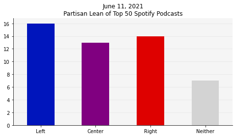

```python
from datetime import date
today_date = date.today().strftime('%B %d, %Y')
fig, ax = plt.subplots(figsize=(8, 4))
colors = ["#0015BC", "purple", "#DE0100", "lightgrey"]
(pod_bias_df.groupby("Partisan Lean")["Source"].count()[["Left", "Center", "Right", "Neither"]]
.plot(ax=ax, kind="bar", color=colors, title=f"{today_date}\nPartisan Lean of Top 50 Spotify Podcasts",
      xlabel="", zorder=2) # place above grid
)
remove_spines(ax)
# ax.tick_params(axis="y", left=False, labelleft=True)
ax.grid(axis="y", alpha=0.2)
ax.tick_params(axis="x", labelrotation=0)
ax.set_facecolor(facecolor)
```

Looks like a fairly even distribution!

Appears to be many podcasts in the 'Neither' category that aren't classified. To resolve this, I will let the user see the podcast names for each category by clicking on the bar. By switching settings, they could also see the source, podcast description, and the description for the most recent episode (all on Spotify).

Later, they could look at intra-category distributions (e.g., progressive vs. neoliberal, lean-left vs. independent, etc.) or other useful stats (self-funded or corporate sponsor?)

Let's put this on GitHub Pages!

### References

- My 'Independent Media' notebook
- Interesting article regarding text analysis in politics
  - http://faculty.washington.edu/jwilker/559/wilkerson_casas_2017.pdf
  - could be useful for next project